# Biostats Lecture 10: Introduction to Regression

## Public Health 783

### Ralph Trane

### University of Wisconsin–Madison<br><br>

### Fall 2019

In 1991, Radelet and Pierce wrote a paper titled "Choosing Those Who Will Die: Race and the Death Penalty in Florida".

Hypothesis: race influences how likely you are to receive the death penalty.

They obtained data on homicides and death sentences from Florida in the period 1976 through 1987.

Data from Agresti [Agr07], originally from http://www.ncjrs.gov/App/publications/abstract.aspx?ID=134288.

Results you are more likely to receive the death penalty if you are white.

In fact, `\(10.97\%\)` of white defendants got the death penalty, while only `\(7.85\%\)` of black defendants received the same verdict.

This is of course not enough to convince you, so let's consider a test for difference in proportions and corresponding CI:

| white | black | statistic | p.value | conf.low | conf.high |
| --- | --- | --- | --- | --- | --- |
| 0.11 | 0.079 | 1.145 | 0.285 | -0.02 | 0.082 |

In a picture:

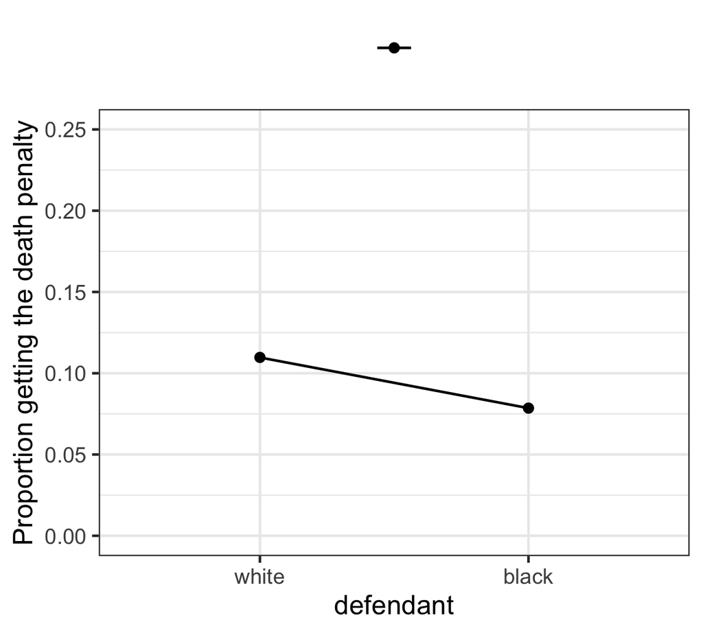

However, this is not the full story. There is one really strong confounding variable, which changes everything. Ideas?

Once we adjust for race of the victim, things change dramatically:

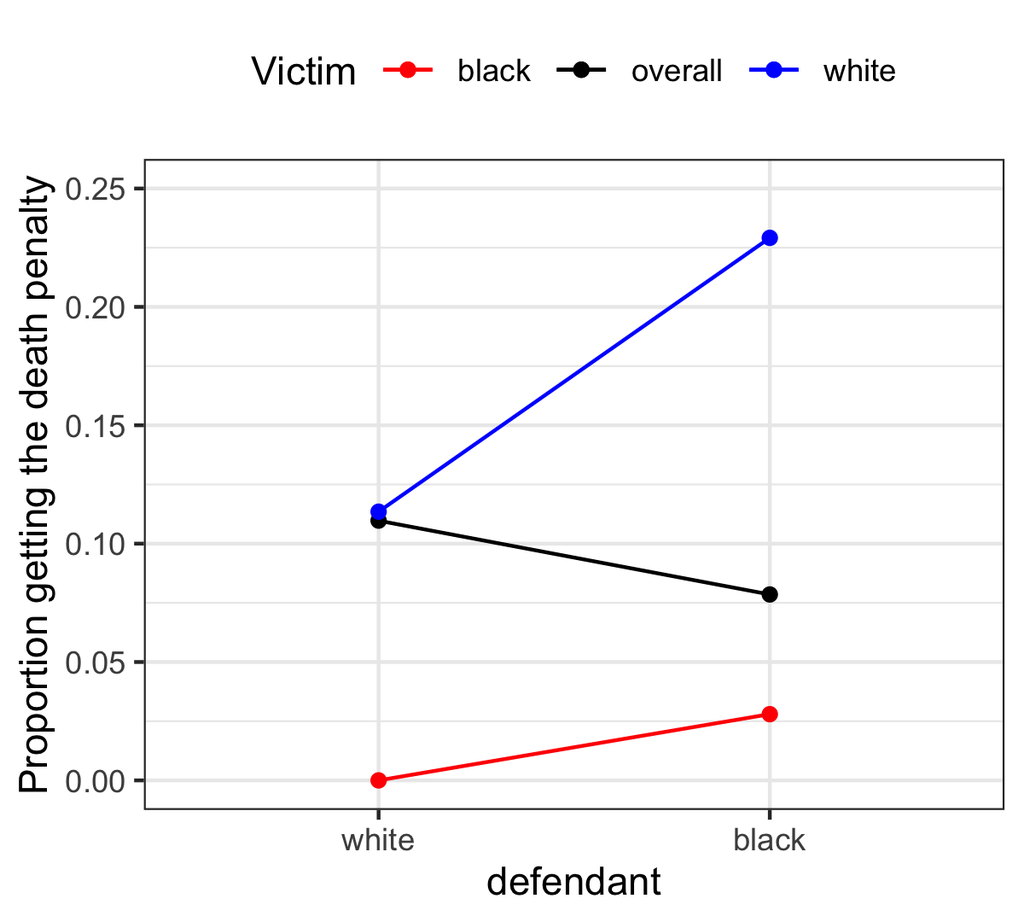

Full data (counts)

| defendant | victim | death_penalty | no_death_penalty | Total |
| --- | --- | --- | --- | --- |
| white | white | 53 (11.3%) | 414 (88.7%) | 467 (100.0%) |
| black | white | 11 (22.9%) | 37 (77.1%) | 48 (100.0%) |
| white | black | 0 (0.0%) | 16 (100.0%) | 16 (100.0%) |
| black | black | 4 (2.8%) | 139 (97.2%) | 143 (100.0%) |
| Total | - | 68 (10.1%) | 606 (89.9%) | 674 (100.0%) |

Issue: race of victim is a strong confounder. I.e. the race of victim influences both race of defendant **and** change of receiving the death penalty.

This is a very simple example, where a regression might not be necessary, but the idea remains: there are situations where you need to correct for confounders. Regression provides a way to do just that.

Result of logistic regression *without* correction:

| term | estimate | std.error | statistic | p.value | conf.low | conf.high |
| --- | --- | --- | --- | --- | --- | --- |
| (Intercept) | -2.093 | 0.146 | -14.380 | 0.000 | -2.390 | -1.818 |
| defendantblack | -0.369 | 0.306 | -1.206 | 0.228 | -1.001 | 0.207 |

Outcome: chance of receiving death penalty.

Interpretation of coefficients: if negative, chance decreases. If positive, chance increases.

Though not "statistically significant", it suggests black defendants less likely to receive death penalty, or at least not more likely.

Result of logistic regression *with* correction:

| term | estimate | std.error | statistic | p.value | conf.low | conf.high |
| --- | --- | --- | --- | --- | --- | --- |
| (Intercept) | -2.059 | 0.146 | -14.121 | 0.000 | -2.356 | -1.784 |
| defendantblack | 0.868 | 0.367 | 2.364 | 0.018 | 0.114 | 1.563 |
| victimblack | -2.404 | 0.601 | -4.004 | 0.000 | -3.718 | -1.307 |

Suggests (and achieves "statistical significance") that defendants who are black are *more* likely to achieve the death penalty, and if the victim was black, the defendant is *less* likely to achieve the death penalty.

A quite different result...

We have talked about how to look for association between two binary variables (difference in proportions), one binary variable and a continous variable (difference in means), and even two categorical variables ( `\(\chi^2\)` test).

Initially, linear regression was introduced to look for an association between two continuous variables.

Say we are looking at two continuous variables (height and weight, for example). What kind of plot would you consider?

Are the two variables related? What does that even mean?

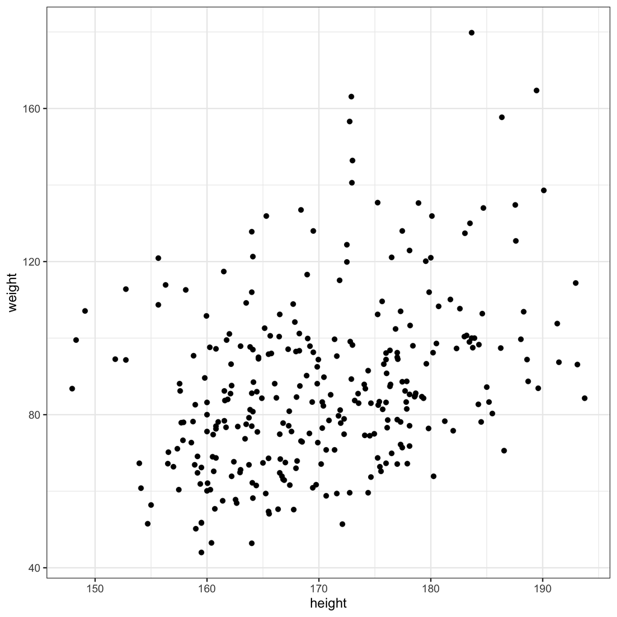

Examples of unrelated variables:

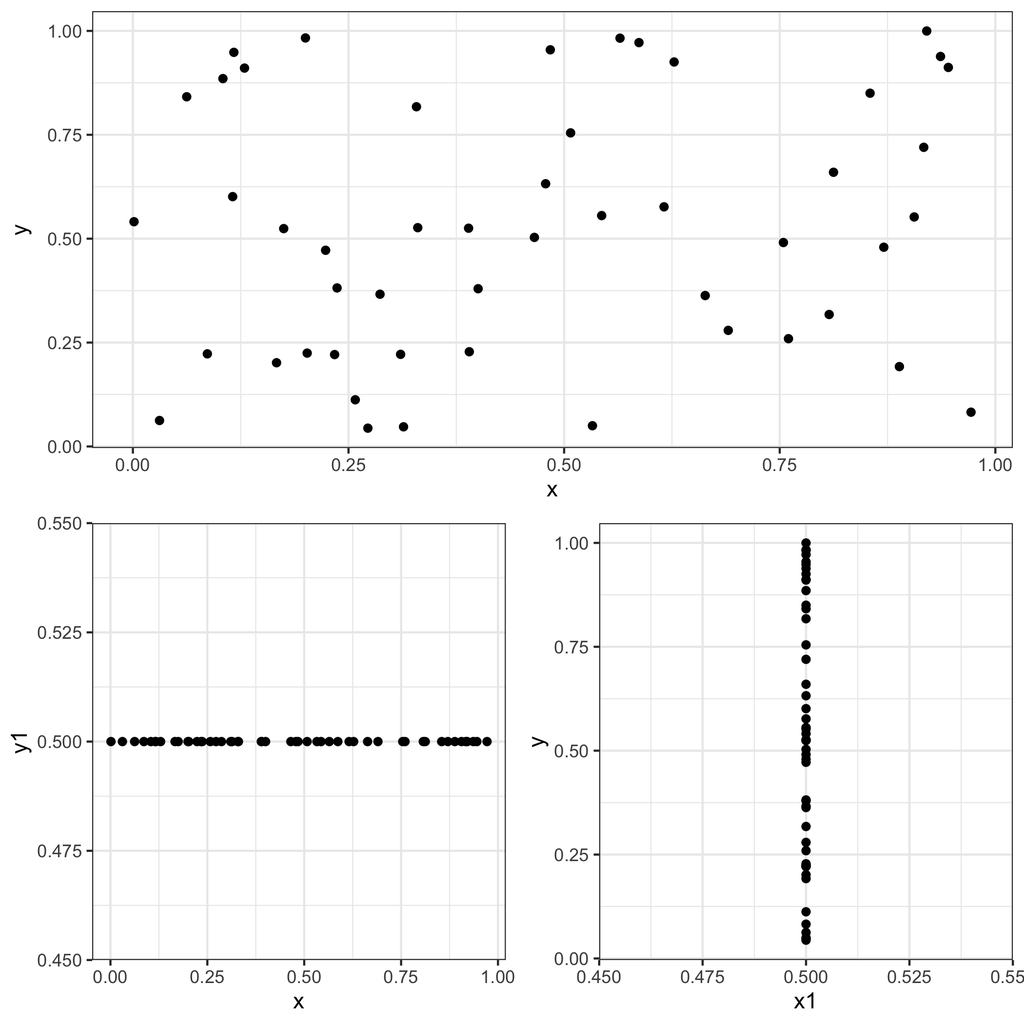

What are we looking for? If "x" gives us any information about "y"

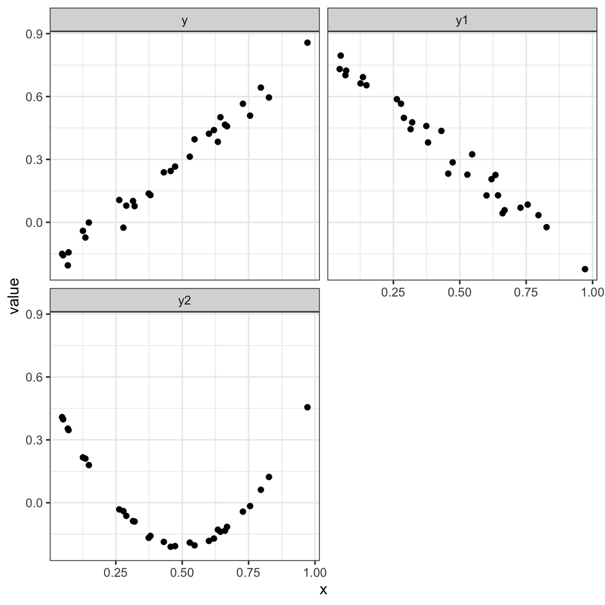

## Simple Linear Regression

The goals is to find "best straight line" to relate `\(Y\)` and `\(X\)`

In math, we assume that `\(Y = \beta_0 + \beta_1\cdot X + \text{noise}\)`.

Assumptions:

* Observations are independent
* The noise is normally distributed with mean `\(0\)`, and it is independent of `\(Y, X\)`.
* There's a linear relationship between `\(X\)` and `\(Y\)`.

Interpretation:

* `\(\beta_0\)` is the intercept. I.e. this is the value of `\(Y\)` when `\(X = 0\)`.
* `\(\beta_1\)` is the slope. When `\(X\)` changes by one unit, `\(Y\)` changes by `\(\beta_1\)` units.

Given `\(\beta_0, \beta_1\)`, and a value for `\(X\)`, we can find the expected value of `\(Y\)`: `\(E(Y) = E(\beta_0 + \beta_1\cdot X + \text{noise}) = \beta_0 + \beta_1\cdot X + E(\text{noise})\)`. Since the noise is assumed to have mean `\(0\)`, this is simply `\(\beta_0 + \beta_1 \cdot X\)`.

## Simple Linear Regression

How do we find good values for `\(\beta_0, \beta_1\)`?

Say our "best guesses" are `\(\hat{\beta}_0, \hat{\beta}_1\)`. Then our best guess for `\(Y\)` is `\(\hat{Y} = \hat{\beta}_0 + \hat{\beta}_1 \cdot X\)`. We want `\(Y - \hat{Y}\)` to be as smalle as possible.

If we have `\(n\)` pairs of observations, `\((X_1, Y_1), ..., (X_n, Y_n)\)`, then we find `\(\hat{\beta}_0, \hat{\beta}_1\)` such that the squared error is as small as possible. I.e., find `\(\hat{\beta}_0, \hat{\beta}_1\)` such that

`\begin{equation}
\sum_{i=1}^n (Y_i - \hat{Y}_i)^2 = \sum_{i=1}^n (Y_i - \hat{\beta}_0 - \hat{\beta}_1\cdot X_i)^2
\end{equation}`

is small.

## Simple Linear Regression

| term | estimate | std.error | statistic | p.value | conf.low | conf.high |
| --- | --- | --- | --- | --- | --- | --- |
| (Intercept) | -57.418 | 22.223 | -2.584 | 0.01 | -101.153 | -13.682 |
| height | 0.851 | 0.130 | 6.526 | 0.00 | 0.594 | 1.107 |

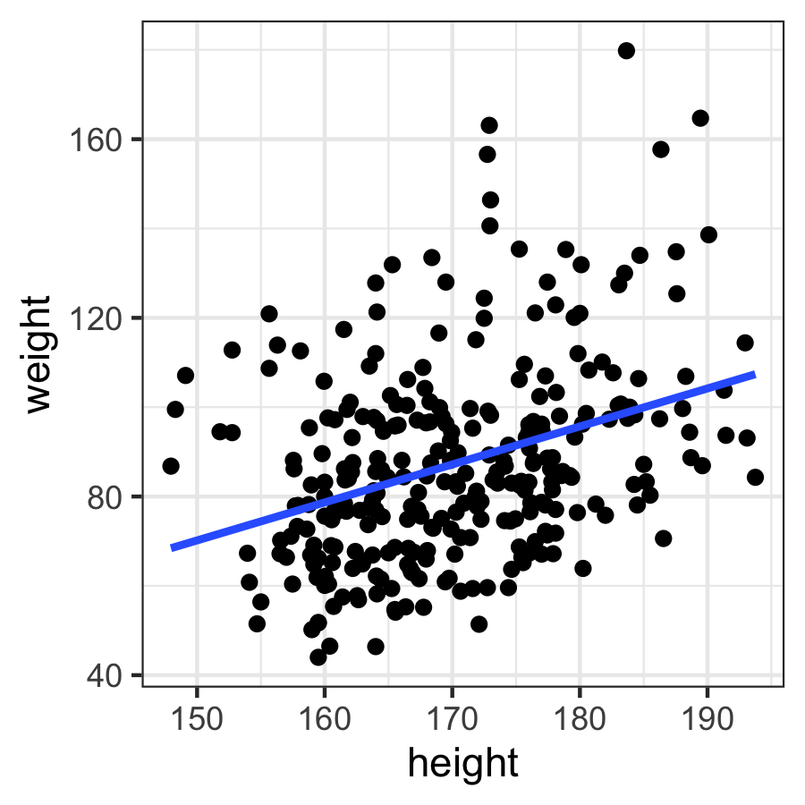

`\(\hat{Y} = -57.418 + 0.851\cdot X\)`

## Multiple Linear Regression

The big seeling point for regression is the ability to adjust for different variables.

To do so, we simply add these to the model: `\(Y = \beta_0 + \beta_1\cdot X_1 + \beta_2 \cdot X_2 + \text{noise}\)`.

How do we find `\(\hat{\beta}_0, \hat{\beta}_1, \hat{\beta}_2\)`? Exactly the same as before! Minimize

`\begin{equation}
\sum_{i=1}^n (Y_i - \hat{Y}_i)^2 = \sum_{i=1}^n (Y_i - \hat{\beta}_0 - \hat{\beta}_1\cdot X_{1,i} - \hat{\beta}_2 \cdot X_{2,i})^2
\end{equation}`

## Multiple Linear Regression

| term | estimate | std.error | statistic | p.value | conf.low | conf.high |
| --- | --- | --- | --- | --- | --- | --- |
| (Intercept) | -33.149 | 32.081 | -1.033 | 0.302 | -96.287 | 29.989 |
| height | 0.719 | 0.181 | 3.975 | 0.000 | 0.363 | 1.075 |
| female | -3.551 | 3.386 | -1.049 | 0.295 | -10.215 | 3.113 |

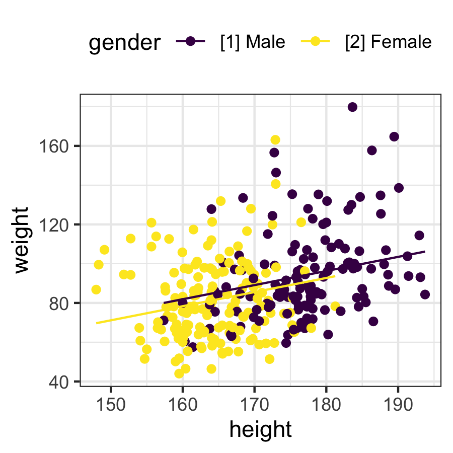

`\begin{align}
\hat{Y} &= -33.149 + 0.719\cdot \text{height} \\
&\qquad + -3.551\cdot \text{gender}
\end{align}`

Remember, this is a model. As George Box is often quoted for saying: "All models are wrong, but some are useful."

How do we know if this is useful? A minimal requirement is that our assumptions aren't way off.

* Observations are independent
    - usually by study design

* There's a linear relationship between `\(X\)` and `\(Y\)`.
    - look at noise plotted against variables. Want it to look "random".

* The noise is normally distributed with mean `\(0\)`, and is independent of `\(Y, X\)`.

For normality, look at QQ-plot. If normal, straight line. For independence, plot noise against variables.

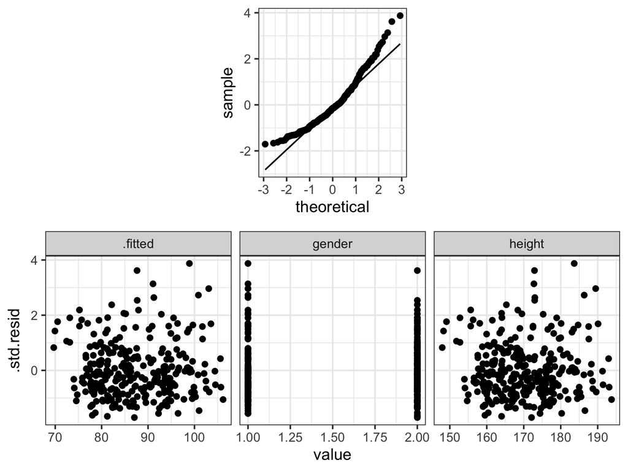

## Multiple Linear Regression

Interpretations: coefficient is effect of "one unit increase, all else being equal".

Effect is after adjusting for other covariates.

| term | estimate | std.error | statistic | p.value | conf.low | conf.high |
| --- | --- | --- | --- | --- | --- | --- |
| (Intercept) | -33.149 | 32.081 | -1.033 | 0.302 | -96.287 | 29.989 |
| height | 0.719 | 0.181 | 3.975 | 0.000 | 0.363 | 1.075 |
| female | -3.551 | 3.386 | -1.049 | 0.295 | -10.215 | 3.113 |

What is the expected/estimated weight of a male subject that is 180cm tall?

`\begin{align*}
  \hat{Y} &= \hat{\beta}_0 + \hat{\beta}_1\cdot \text{height} + \hat{\beta}_2 \cdot \text{female} \\
          &= -33.15 + 0.72 180 -3.55 \cdot 0 \\
          &= 96.45.
\end{align*}`

Word of caution: we cannot extrapolate this outside of the range of the data. For example, it makes no sense to use this model to predict the weight of someone who is 199 cm tall, as the tallest subject in our data set is 193.75 cm tall.

# References

Agresti, A. (2007). _An Introduction to Categorical Data Analysis_. 2nd
ed. Wiley Series in Probability and Mathematical Statistics. OCLC:
ocm71812851. Hoboken, NJ: Wiley-Interscience. ISBN: 978-0-471-22618-5.